# Pairs Trading Strategy

Aleksandra Tatko

2025-09-08

# **Step 1: Install Required Libraries**

# **Step 2: Data Collection**

We’ll choose Coca-Cola (KO) and PepsiCo (PEP) as our stock pair example and fetch their historical prices.

```r
library(quantmod)

# Fetch historical stock price data
symbols <- c("KO", "PEP")
getSymbols(symbols, from = "2010-01-01", to = Sys.Date())
```

```
[1] "KO"  "PEP"
```

```r
# Extract adjusted closing prices
ko_prices <- Cl(KO)
pep_prices <- Cl(PEP)
```

# **Step 3: Correlation and Co-Integration Analysis**

We perform two key tests:

**1. Correlation Test:**

- We calculate the correlation between the daily returns of the two stocks to verify if they have historically moved together.
- A high correlation suggests that the two stocks tend to move in the same direction.

**2. Co-Integration Test:**

- Correlation alone is not sufficient for pairs trading; the stocks must also be co-integrated. Co-integration implies that despite the short-term fluctuations, there exists a long-term equilibrium relationship between the two stocks.

The Johansen test was used to determine if KO and PEP are co-integrated. The test identifies whether a stationary linear combination exists between the two non-stationary price series (KO and PEP), indicating that they share a common stochastic trend.

```r
library(urca)
# Calculate the daily returns for KO and PEP
ko_returns <- dailyReturn(Cl(KO))
pep_returns <- dailyReturn(Cl(PEP))

# Calculate the Pearson correlation between the daily returns
pearson_correlation <- cor(ko_returns, pep_returns, method = "pearson")
print(pearson_correlation)
```

```
              daily.returns
daily.returns     0.6911681
```

```r
# Convert the prices to a data frame for the co-integration test
price_data <- cbind(Cl(KO), Cl(PEP))
colnames(price_data) <- c("KO", "PEP")
# Perform the Johansen co-integration test
johansen_test <- ca.jo(price_data, type = "trace", ecdet = "none", K = 2)

# Display the summary of the Johansen test
summary(johansen_test)
```

```
######################
# Johansen-Procedure #
######################

Test type: trace statistic , with linear trend

Eigenvalues (lambda):
[1] 0.0012996209 0.0005199643

Values of teststatistic and critical values of test:

         test 10pct  5pct  1pct
r <= 1 | 2.05  6.50  8.18 11.65
r = 0  | 7.17 15.66 17.95 23.52

Eigenvectors, normalised to first column:
(These are the cointegration relations)

            KO.l2    PEP.l2
KO.l2   1.0000000  1.000000
PEP.l2 -0.2576671 -1.230535

Weights W:
(This is the loading matrix)

             KO.l2       PEP.l2
KO.d  -0.004203943 8.491449e-05
PEP.d -0.005640068 7.507499e-04
```

# **Step 4a: Spread Calculation and Stationarity Test**

Calculate the price spread and perform the ADF test to verify its stationarity.

**Purpose**: The spread’s behavior helps us identify whether deviations between the stock prices are temporary and likely to revert, which is the foundation of the pairs trading strategy.

```r
# The spread is calculated as the difference between the prices of KO and PEP:
spread <- Cl(KO) - Cl(PEP)

# We then test the spread's stationarity using the Augmented Dickey-Fuller (ADF) test to confirm that the spread tends to revert to a mean value over time (a key assumption for pairs trading).
adf_test <- adf.test(spread)
print(adf_test)
```

```
    Augmented Dickey-Fuller Test

data:  spread
Dickey-Fuller = -1.7089, Lag order = 15, p-value = 0.7016
alternative hypothesis: stationary
```

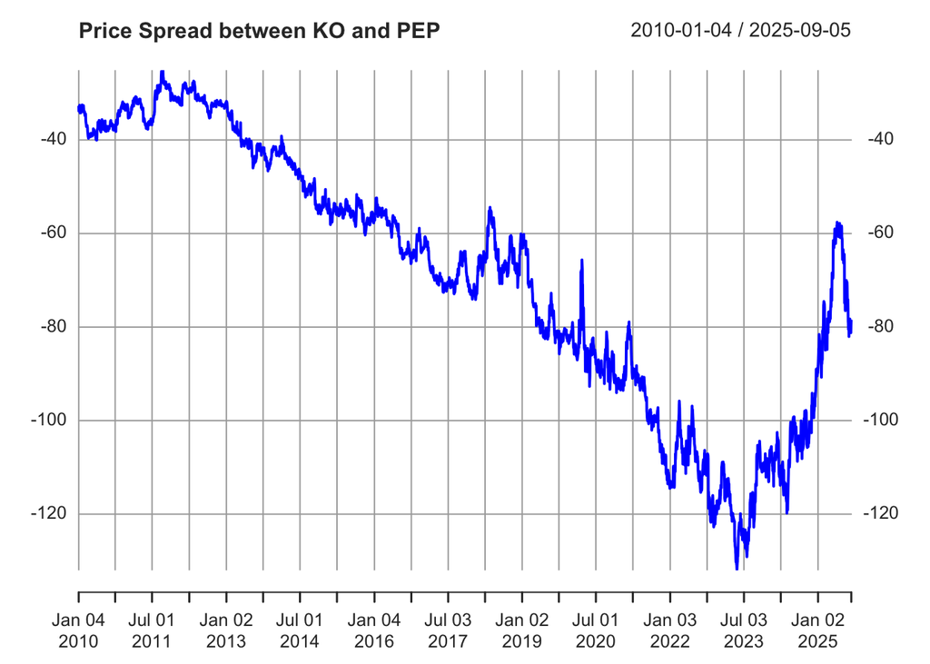

```r
# Plot the spread
plot(spread, main = "Price Spread between KO and PEP", col = "blue")
```

**Interpretation of the plot:**

- The spread shows both short-term mean reversion (which is a positive indicator for pairs trading) and a long-term trend (which could require adjustments or consideration of external factors affecting the stocks).
- For pairs trading to be effective, it’s important to capitalize on the short-term oscillations while being mindful of the long-term trend.

# **Step 4b: Short term focus**

If we want to focus on a short term mean reverion opportunities we use the rolling window, that can be adjusted based of the specific analysis, industry, requirements, etc. ( in our example 60 days), to capture shorter-term fluctuations in the spread.

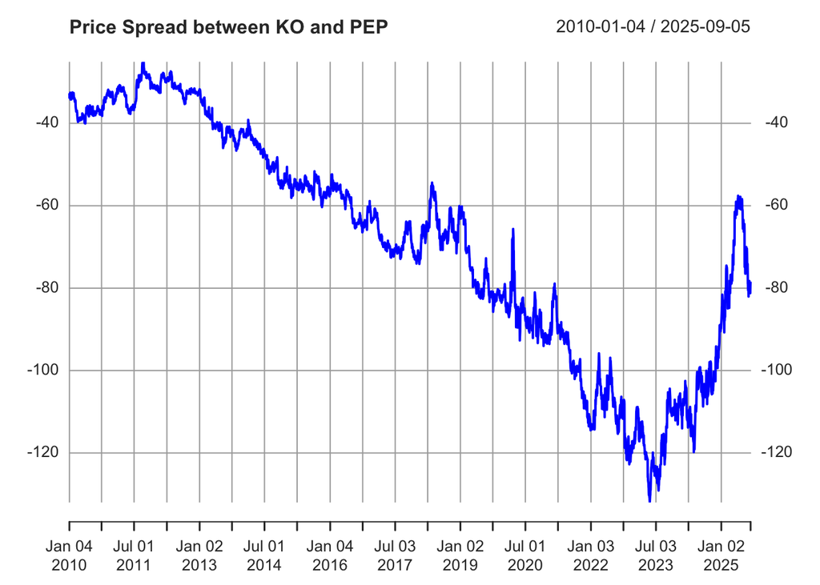

```r
# Load necessary libraries
library(quantmod)
library(TTR)

# Define the window size for rolling calculations (e.g., 60 days)
window_size <- 60

# Calculate the rolling mean and rolling standard deviation of the spread
rolling_mean <- runMean(spread, n = window_size)
rolling_sd <- runSD(spread, n = window_size)

# Calculate the Z-score based on rolling statistics
z_score <- (spread - rolling_mean) / rolling_sd

# Plot the spread and the rolling mean
plot(spread, main = "Price Spread between KO and PEP", col = "blue")
```

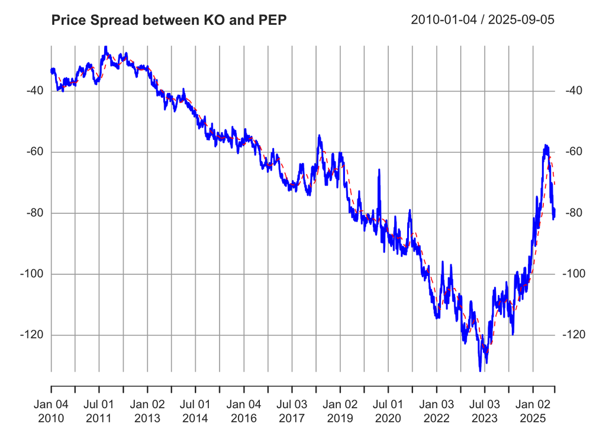

```r
lines(rolling_mean, col = "red", lty = 2)
abline(h = 0, col = "black", lty = 3)
```

**Interpretation**

- The red dashed line represents the rolling mean of the spread calculated over a set window size (60 days). It smooths out short-term fluctuations to highlight the average behavior of the spread within the chosen period. The rolling mean helps visualize the short-term trends of the spread, showing when the spread is generally above or below its short-term average.
- In many segments of the plot, the blue line (spread) oscillates around the red dashed line (rolling mean), indicating that the spread reverts to the mean after deviating. This behavior is essential for mean-reversion strategies like pairs trading.

# **Step 5: Calculate Z-Score for Trading Signals**

We calculate the Z-score of the spread, which measures how far the spread deviates from its mean in terms of standard deviations.

**Purpose**: This Z-score helps us understand if the spread is significantly different from its average, which can be used as a signal to enter or exit trades.

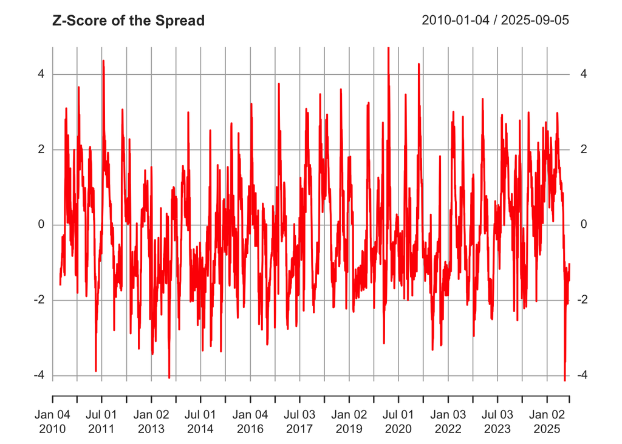

```r
library(TTR)

# Calculate rolling mean and standard deviation of the spread
window_size <- 60
rolling_mean <- runMean(spread, n = window_size)
rolling_sd <- runSD(spread, n = window_size)

# Calculate Z-score
z_score <- (spread - rolling_mean) / rolling_sd

# Plot the Z-score
plot(z_score, type = "l", main = "Z-Score of the Spread", col = "red")
abline(h = c(-2, 2), col = "blue", lty = 2)
```

**Threshold Choice:** The ±2 Z-score thresholds indicate points where the spread is significantly deviated from its mean (beyond 2 standard deviations). This is a common practice in pairs trading to define when a spread is sufficiently diverged to justify entering a trade:

- **Z-score < -2:** The spread is lower than expected, suggesting that KO may be undervalued relative to PEP. The strategy would initiate a long position on KO and a short position on PEP, expecting the spread to narrow (revert to the mean).
- **Z-score > 2:** The spread is higher than expected, indicating that KO may be overvalued relative to PEP. The strategy would take a short position on KO and a long position on PEP, anticipating the spread to decrease.

# **Step 6: Trading Logic Implementation**

**Purpose:** This step sets up the trading strategy, defining when to enter and exit positions based on the behavior of the spread relative to its historical average.

We use the Z-score to create trading rules:

## **Entry Signals**

**1. When the Z-score is below -2:**

- This indicates that the spread is significantly below its average level (by more than two standard deviations). In this case:
  - The strategy **buys** Coca-Cola (KO) and **sells** PepsiCo (PEP).
  - This position assumes that the spread is undervalued and will revert to the mean, making KO relatively cheaper than PEP. By going long KO and short PEP, the expectation is that KO’s price will rise or PEP’s price will fall (or both), closing the gap.

**2.When the Z-score is above 2:**

- This indicates that the spread is significantly above its average level (by more than two standard deviations). In this case:
  - The strategy **sells** Coca-Cola (KO) and **buys** PepsiCo (PEP).
  - This position assumes that the spread is overvalued and will revert to the mean, making KO relatively expensive compared to PEP. By shorting KO and going long PEP, the expectation is that KO’s price will fall or PEP’s price will rise (or both), reducing the spread.

## **Exit Signal**

The strategy closes its position when the Z-score returns to around 0. This implies that the spread has reverted to its mean, and the trading opportunity has completed. By exiting at this point:

- The strategy locks in profits based on the movement of KO and PEP prices back to their expected relationship.
- Exiting at a Z-score of 0 ensures that the trade captures the mean reversion, which is the central concept behind pairs trading.

## **Backtesting**

We apply the strategy rules to historical prices and track the performance as if we were trading in real-time.

**1. Data Splitting:**

The dataset is split into training (70%) and testing (30%) portions. The training set is used for developing and refining the strategy, while the test set evaluates how the strategy performs on unseen data. This split prevents overfitting, ensuring the strategy generalizes well beyond historical data.

```r
# Load necessary libraries
library(quantmod)
library(TTR)
library(PerformanceAnalytics)
library(xts)

# Fetch historical stock price data
symbols <- c("KO", "PEP")
getSymbols(symbols, from = "2010-01-01", to = Sys.Date())
```

```
[1] "KO"  "PEP"
```

```r
# Extract adjusted closing prices
ko_prices <- Cl(KO)
pep_prices <- Cl(PEP)

# Calculate the spread between KO and PEP
spread <- ko_prices - pep_prices

# Define the rolling window size for Z-score calculation
window_size <- 60
rolling_mean <- runMean(spread, n = window_size)
rolling_sd <- runSD(spread, n = window_size)
z_score <- (spread - rolling_mean) / rolling_sd

# Split data into training and test sets (70% for training, 30% for testing)
split_index <- floor(0.7 * length(z_score))
z_score_train <- z_score[1:split_index]
z_score_test <- z_score[(split_index + 1):length(z_score)]
```

- In the code, a transaction cost is set to 0.1% per trade.
- We set initial amount of money to start the strategy to 100,000.
- We set the the number of shares to tradce for each signal to 100.
- Created loop runs through the entire time series of Z-scores and applies the trading rules based on the thresholds set in the steps before.

```r
# Set initial capital and transaction cost
capital <- 100000  # Initial capital
transaction_cost <- 0.001  # 0.1% per trade
position <- 0
position_size <- 100
pnl <- numeric(length(z_score_test))  # Array to track PnL

# Backtesting trading logic on test data
for (i in 2:length(z_score_test)) {
  if (!is.na(z_score_test[i])) {
    if (z_score_test[i] < -2 && position == 0) {
      # Enter long position on KO, short on PEP
      position <- position_size
      pnl[i] <- pnl[i-1] - (Cl(KO)[split_index + i] * position_size * (1 + transaction_cost)) +
                 (Cl(PEP)[split_index + i] * position_size * (1 - transaction_cost))
    } else if (z_score_test[i] > 2 && position == 0) {
      # Enter short position on KO, long on PEP
      position <- -position_size
      pnl[i] <- pnl[i-1] + (Cl(KO)[split_index + i] * position_size * (1 - transaction_cost)) -
                 (Cl(PEP)[split_index + i] * position_size * (1 + transaction_cost))
    } else if (abs(z_score_test[i]) < 0.5 && position != 0) {
      # Exit position
      pnl[i] <- pnl[i-1] + position * (Cl(KO)[split_index + i] - Cl(PEP)[split_index + i]) -
                 abs(position) * transaction_cost * (Cl(KO)[split_index + i] + Cl(PEP)[split_index + i]) / 2
      position <- 0
    } else {
      pnl[i] <- pnl[i-1]  # No change in PnL if no action
    }
  }
}

# Convert pnl to a time series (xts object) using the appropriate date index
date_index <- index(z_score_test)[-1]  # Adjust the index length to match pnl length
pnl_ts <- xts(pnl[-1], order.by = date_index)

# Calculate daily returns based on PnL changes
daily_returns <- diff(pnl_ts) / lag(pnl_ts, k = 1)
daily_returns <- na.omit(daily_returns)
daily_returns <- daily_returns[is.finite(daily_returns)]
```

## **Performance Metrics**

These metrics provide insight into how profitable and risky the strategy would have been historically.

```r
# Calculate performance metrics
sharpe_ratio <- ifelse(sd(daily_returns) > 0, SharpeRatio.annualized(daily_returns, scale = 252), NA)
max_drawdown <- maxDrawdown(daily_returns)

# Print the performance metrics
mean_return <- mean(daily_returns)
sd_return <- sd(daily_returns)

print(paste("Mean Return:", mean_return))
```

```
[1] "Mean Return: -0.0236296639774326"
```

```r
print(paste("Standard Deviation:", sd_return))
```

```
[1] "Standard Deviation: 2.84652127048514"
```

```r
print(paste("Sharpe Ratio:", sharpe_ratio))
```

```
[1] "Sharpe Ratio: NaN"
```

```r
print(paste("Max Drawdown:", max_drawdown))
```

```
[1] "Max Drawdown: 2.08294909358605"
```

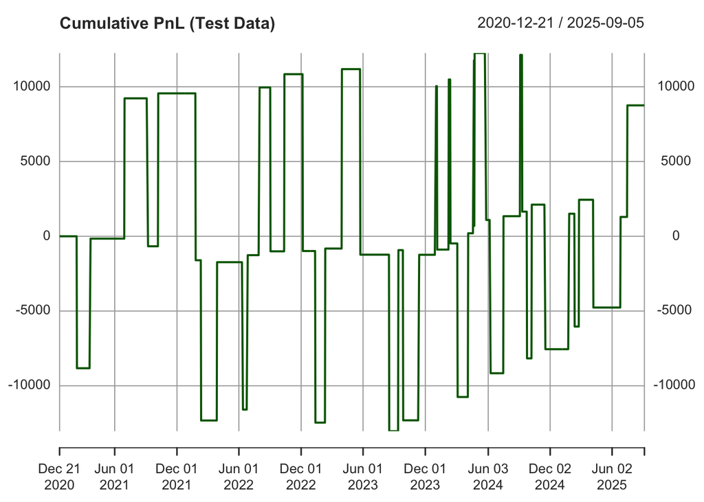

```r
# Plot the cumulative PnL
plot(pnl_ts, type = "l", main = "Cumulative PnL (Test Data)", col = "darkgreen")
```

## **Interpretation of the Cumulative PnL Plot**

The plot shows the Cumulative PnL (Profit and Loss) of the pairs trading strategy over time. It is a critical part of the backtest that visualizes how the strategy performs as trades are executed based on the Z-score thresholds.

**1. Y-Axis (PnL):**

- The y-axis represents the cumulative profit or loss in monetary units over time. Positive values indicate profit, while negative values indicate losses.
- The range shows the volatility and profitability of the strategy, with the values fluctuating as trades are entered and exited.

**2. X-Axis (Index):**

- The x-axis represents the time or the sequence of trades/events. Each point corresponds to a time step in the dataset where the strategy might have entered or exited a trade.
- It shows the progression of the strategy over the entire backtesting period.

**3. Cumulative PnL Line (Green Line):**

- The green line represents the cumulative profit or loss generated by the strategy. It moves up and down as trades are made based on the Z-score crossing the thresholds (±2) and subsequently reverting to the mean (Z-score returning to 0).
- **Upward Movements:** When the line moves up, it indicates that the strategy has entered a profitable trade (the spread has reverted as expected).
- **Downward Movements:** When the line dips, it shows that the strategy experienced a loss, potentially because the spread did not revert as expected or because of a false signal.

## **Solving the Sharpe Ratio issue**

To solve the NaN Sharpe ratio issue we lowered Z-Score Threshold:

- Entry Threshold (z_score_entry): Adjusted to 1 from the original 2. This change makes the strategy more sensitive to smaller deviations from the mean, increasing the frequency of trades.
- Exit Threshold (z_score_exit): Kept at 0.5 to maintain consistency for exiting trades when the spread reverts closer to the mean.

By lowering the Z-score threshold, the strategy will likely generate more trades, providing variability in the daily returns.

```r
# Load necessary libraries
library(quantmod)
library(TTR)
library(PerformanceAnalytics)
library(xts)

# Fetch historical stock price data
symbols <- c("KO", "PEP")
getSymbols(symbols, from = "2010-01-01", to = Sys.Date())
```

```
[1] "KO"  "PEP"
```

```r
# Extract adjusted closing prices
ko_prices <- Cl(KO)
pep_prices <- Cl(PEP)

# Calculate the spread between KO and PEP
spread <- ko_prices - pep_prices

# Define the rolling window size for Z-score calculation
window_size <- 60
rolling_mean <- runMean(spread, n = window_size)
rolling_sd <- runSD(spread, n = window_size)
z_score <- (spread - rolling_mean) / rolling_sd

# Adjust Z-score thresholds to generate more trading signals
z_score_entry <- 1.00  # Entry threshold (lowered from 2)
z_score_exit <- 0.5   # Exit threshold (unchanged)

# Split data into training and test sets (70% for training, 30% for testing)
split_index <- floor(0.7 * length(z_score))
z_score_train <- z_score[1:split_index]
z_score_test <- z_score[(split_index + 1):length(z_score)]

# Set initial capital and transaction cost
capital <- 100000  # Initial capital
transaction_cost <- 0.001  # 0.1% per trade
position <- 0
position_size <- 100
pnl <- numeric(length(z_score_test))  # Array to track PnL

# Backtesting trading logic on test data
for (i in 2:length(z_score_test)) {
  if (!is.na(z_score_test[i])) {
    if (z_score_test[i] < -z_score_entry && position == 0) {
      # Enter long position on KO, short on PEP
      position <- position_size
      pnl[i] <- pnl[i-1] - (Cl(KO)[split_index + i] * position_size * (1 + transaction_cost)) +
                (Cl(PEP)[split_index + i] * position_size * (1 - transaction_cost))
    } else if (z_score_test[i] > z_score_entry && position == 0) {
      # Enter short position on KO, long on PEP
      position <- -position_size
      pnl[i] <- pnl[i-1] + (Cl(KO)[split_index + i] * position_size * (1 - transaction_cost)) -
                (Cl(PEP)[split_index + i] * position_size * (1 + transaction_cost))
    } else if (abs(z_score_test[i]) < z_score_exit && position != 0) {
      # Exit position
      pnl[i] <- pnl[i-1] + position * (Cl(KO)[split_index + i] - Cl(PEP)[split_index + i]) -
                abs(position) * transaction_cost * (Cl(KO)[split_index + i] + Cl(PEP)[split_index + i]) / 2
      position <- 0
    } else {
      pnl[i] <- pnl[i-1]  # No change in PnL if no action
    }
  }
}

# Adjust the length of pnl to match the index of z_score_test
date_index <- index(z_score_test)[-1]  # Adjust the index length to match pnl length
pnl_ts <- xts(pnl[-1], order.by = date_index)

# Calculate daily returns based on PnL changes
daily_returns <- diff(pnl_ts) / lag(pnl_ts, k = 1)
daily_returns <- na.omit(daily_returns)
daily_returns <- daily_returns[is.finite(daily_returns)]

# Calculate performance metrics
sharpe_ratio <- ifelse(sd(daily_returns) > 0, SharpeRatio.annualized(daily_returns, scale = 252), NA)
max_drawdown <- maxDrawdown(daily_returns)

# Print the performance metrics
mean_return <- mean(daily_returns)
sd_return <- sd(daily_returns)

print(paste("Mean Return:", mean_return))
```

```
[1] "Mean Return: 0.0431926101874679"
```

```r
print(paste("Standard Deviation:", sd_return))
```

```
[1] "Standard Deviation: 4.79443212320285"
```

```r
print(paste("Sharpe Ratio:", sharpe_ratio))
```

```
[1] "Sharpe Ratio: 0.000124665957576067"
```

```r
print(paste("Max Drawdown:", max_drawdown))
```

```
[1] "Max Drawdown: 1.97143835604599"
```

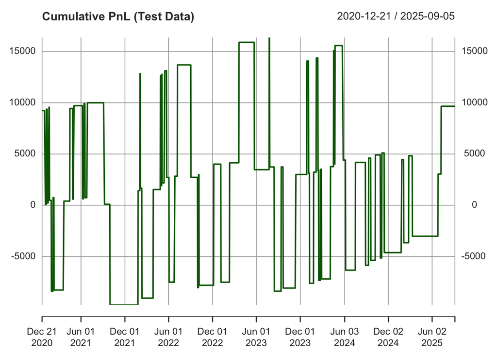

```r
# Plot the cumulative PnL
plot(pnl_ts, type = "l", main = "Cumulative PnL (Test Data)", col = "darkgreen")
```

# **Step 7: Incorporate Stop-Loss Levels**

Define Stop-Loss Threshold:

- We’ll set a percentage loss limit, such as 2% of the capital per trade. If the loss on a trade exceeds this limit, the trade will be exited.

```r
# Set initial capital and transaction cost
capital <- 100000  # Initial capital
transaction_cost <- 0.001  # 0.1% per trade
stop_loss_threshold <- 0.02 * capital  # 2% of capital per trade as stop-loss
position <- 0
position_size <- 100
pnl <- numeric(length(z_score_test))  # Array to track PnL

# Backtesting trading logic on test data
for (i in 2:length(z_score_test)) {
  if (!is.na(z_score_test[i])) {
    # Enter long position on KO, short on PEP
    if (z_score_test[i] < -2 && position == 0) {
      position <- position_size
      pnl[i] <- pnl[i-1] - (Cl(KO)[split_index + i] * position_size * (1 + transaction_cost)) +
                (Cl(PEP)[split_index + i] * position_size * (1 - transaction_cost))
    }
    # Enter short position on KO, long on PEP
    else if (z_score_test[i] > 2 && position == 0) {
      position <- -position_size
      pnl[i] <- pnl[i-1] + (Cl(KO)[split_index + i] * position_size * (1 - transaction_cost)) -
                (Cl(PEP)[split_index + i] * position_size * (1 + transaction_cost))
    }
    # Exit position if z-score is near zero or stop-loss is hit
    else if (abs(z_score_test[i]) < 0.5 && position != 0) {
      # Calculate current loss/gain
      current_pnl <- pnl[i-1] + position * (Cl(KO)[split_index + i] - Cl(PEP)[split_index + i]) -
                     abs(position) * transaction_cost * (Cl(KO)[split_index + i] + Cl(PEP)[split_index + i]) / 2

      # If loss exceeds stop-loss threshold, exit the trade
      if (abs(current_pnl - pnl[i-1]) > stop_loss_threshold) {
        pnl[i] <- pnl[i-1]  # No further change in PnL if stop-loss triggers
        position <- 0
      } else {
        pnl[i] <- current_pnl
        position <- 0
      }
    } else {
      pnl[i] <- pnl[i-1]  # No change in PnL if no action
    }
  }
}
```

```r
# Load necessary libraries
library(quantmod)
library(TTR)
library(PerformanceAnalytics)
library(xts)

# Fetch historical stock price data
symbols <- c("KO", "PEP")
getSymbols(symbols, from = "2010-01-01", to = Sys.Date())
```

```
[1] "KO"  "PEP"
```

```r
# Extract adjusted closing prices
ko_prices <- Cl(KO)
pep_prices <- Cl(PEP)

# Calculate the spread between KO and PEP
spread <- ko_prices - pep_prices

# Define the rolling window size for Z-score calculation
window_size <- 60
rolling_mean <- runMean(spread, n = window_size)
rolling_sd <- runSD(spread, n = window_size)
z_score <- (spread - rolling_mean) / rolling_sd

# Split data into training and test sets (70% for training, 30% for testing)
split_index <- floor(0.7 * length(z_score))
z_score_train <- z_score[1:split_index]
z_score_test <- z_score[(split_index + 1):length(z_score)]

# Set initial capital, transaction cost, and stop-loss threshold
capital <- 100000  # Initial capital
transaction_cost <- 0.001  # 0.1% per trade
stop_loss_threshold <- 0.02 * capital  # 2% of capital per trade as stop-loss
position <- 0
position_size <- 100
pnl <- numeric(length(z_score_test))  # Array to track PnL

# Backtesting trading logic on test data
for (i in 2:length(z_score_test)) {
  if (!is.na(z_score_test[i])) {
    # Enter long position on KO, short on PEP
    if (z_score_test[i] < -2 && position == 0) {
      position <- position_size
      pnl[i] <- pnl[i-1] - (Cl(KO)[split_index + i] * position_size * (1 + transaction_cost)) +
                (Cl(PEP)[split_index + i] * position_size * (1 - transaction_cost))
    }
    # Enter short position on KO, long on PEP
    else if (z_score_test[i] > 2 && position == 0) {
      position <- -position_size
      pnl[i] <- pnl[i-1] + (Cl(KO)[split_index + i] * position_size * (1 - transaction_cost)) -
                (Cl(PEP)[split_index + i] * position_size * (1 + transaction_cost))
    }
    # Exit position if z-score is near zero or stop-loss is hit
    else if (abs(z_score_test[i]) < 0.5 && position != 0) {
      # Calculate current loss/gain
      current_pnl <- pnl[i-1] + position * (Cl(KO)[split_index + i] - Cl(PEP)[split_index + i]) -
                    abs(position) * transaction_cost * (Cl(KO)[split_index + i] + Cl(PEP)[split_index + i]) / 2

      # If loss exceeds stop-loss threshold, exit the trade
      if (abs(current_pnl - pnl[i-1]) > stop_loss_threshold) {
        pnl[i] <- pnl[i-1]  # No further change in PnL if stop-loss triggers
        position <- 0
      } else {
        pnl[i] <- current_pnl
        position <- 0
      }
    } else {
      pnl[i] <- pnl[i-1]  # No change in PnL if no action
    }
  }
}

# Adjust the length of pnl to match the index of z_score_test
date_index <- index(z_score_test)[-1]  # Adjust the index length to match pnl length
pnl_ts <- xts(pnl[-1], order.by = date_index)

# Calculate daily returns based on PnL changes
daily_returns <- diff(pnl_ts) / lag(pnl_ts, k = 1)
daily_returns <- na.omit(daily_returns)
daily_returns <- daily_returns[is.finite(daily_returns)]

# Calculate performance metrics
sharpe_ratio <- ifelse(sd(daily_returns) > 0, SharpeRatio.annualized(daily_returns, scale = 252), NA)
max_drawdown <- maxDrawdown(daily_returns)

# Print the performance metrics
mean_return <- mean(daily_returns)
sd_return <- sd(daily_returns)

print(paste("Mean Return:", mean_return))
```

```
[1] "Mean Return: -0.0906504535547339"
```

```r
print(paste("Standard Deviation:", sd_return))
```

```
[1] "Standard Deviation: 4.56538029483765"
```

```r
print(paste("Sharpe Ratio:", sharpe_ratio))
```

```
[1] "Sharpe Ratio: -0.00836352587097423"
```

```r
print(paste("Max Drawdown:", max_drawdown))
```

```
[1] "Max Drawdown: 3.72078957438052"
```

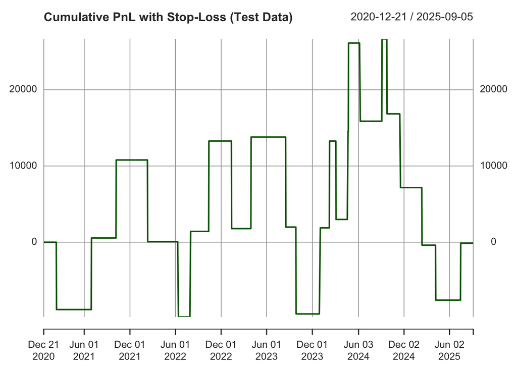

```r
# Plot the cumulative PnL
plot(pnl_ts, type = "l", main = "Cumulative PnL with Stop-Loss (Test Data)", col = "darkgreen")
```